# Análise de Gastos de Deputados: Suas Perguntas

Gabriel Moras Lúcio de Araújo

7 de novembro de 2017

```r
dadosCEAP <- read.csv("~/Github/analiseDeDados/dados/dadosCEAP.csv", encoding = "UTF-8")
dadosLimiteCEAP <- read.csv("~/Github/analiseDeDados/dados/limiteMensalCEAP.csv", encoding = "UTF-8")
```

### 1. Quais são os fornecedores com mais usos da CEAP? E levando em conta o valor gasto em R$?

**Expectativa:** *Acredito que os fornecedores com mais usos da CEAP serão os que provem as despesas com mais usos da CEAP.* Vejamos o que as seguintes visualizações podem nos dizer:

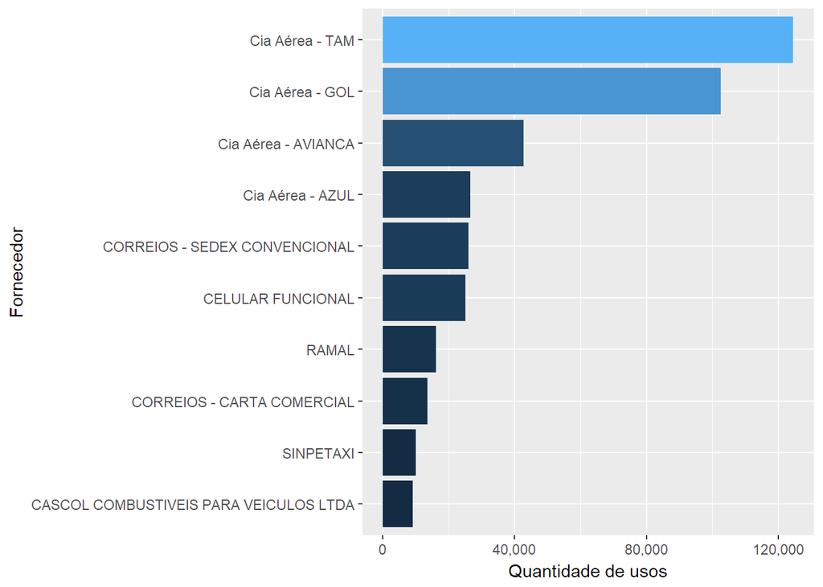

```r
dados.cont.fornecedor <- dadosCEAP %>%
  group_by(fornecedor) %>%
  summarise(count = n()) %>%
  arrange(desc(count)) %>%
  na.omit()

fornecedor.top10 <- dados.cont.fornecedor %>% top_n(10)

dados.sum.fornecedor <- dadosCEAP %>%
  group_by(fornecedor) %>%
  summarise(total = sum(valorDocumento)) %>%
  arrange(desc(total)) %>%
  na.omit()

fornecedor.gastotop10 <- dados.sum.fornecedor %>% top_n(10)

ggplot(fornecedor.top10, aes(x = reorder(fornecedor, count), y = count, fill = count)) +
  geom_bar(stat = "identity") +
  guides(fill = FALSE) +
  scale_y_continuous(labels = scales::comma) +
  coord_flip() +
  labs("Fornecedaores com mais usos da CEAP", x = "Fornecedor", y = "Quantidade de usos")
```

Agora analisando os gastos em R$:

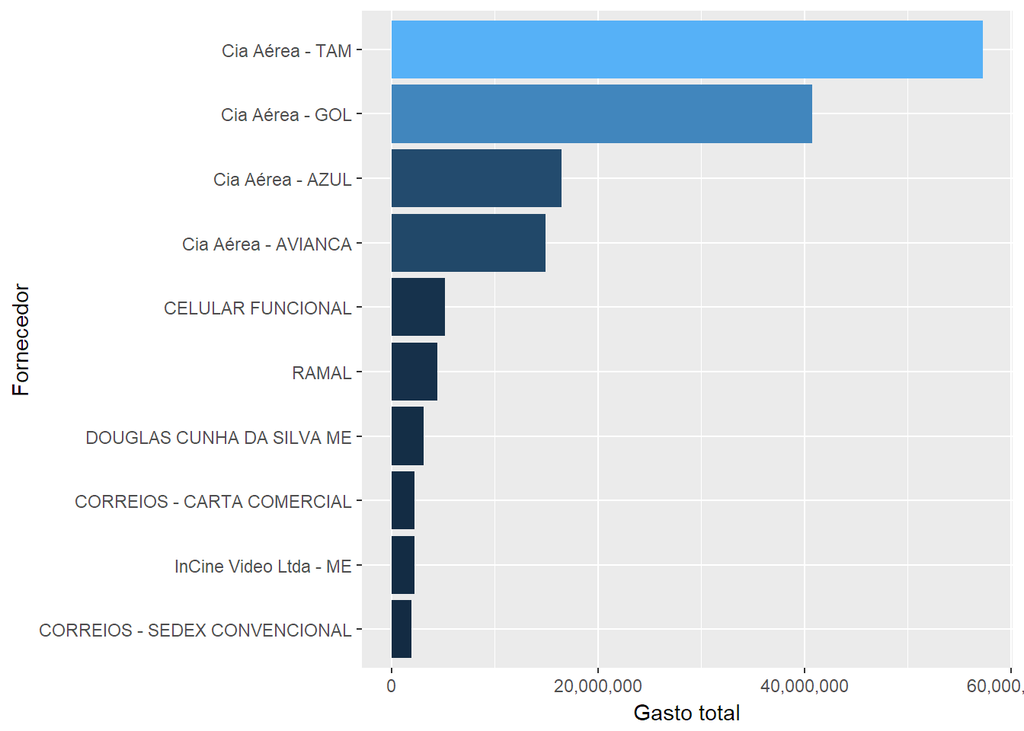

```r
ggplot(fornecedor.gastotop10, aes(x = reorder(fornecedor, total), y = total, fill = total)) +
  geom_bar(stat = "identity") +
  guides(fill = FALSE) +
  scale_y_continuous(labels = scales::comma) +
  coord_flip() +
  labs("Fornecedaores com mais gastos da CEAP", x = "Fornecedor", y = "Gasto total")
```

Como podemos ver, em ambos os casos (uso e gasto total) as despesas envolvendo bilhetes aéreo são as que mais gastam e são utilizadas pelos parlamentares.

### 2. Existe correlação entre o número de deputados de um estado e o limite mensal da CEAP?

**Expectativa:** *Os estados com maior número de deputados devem ter limite mensal menor para que o gasto total não seja muito alto.*

```r
dados.cont.deputado <- dadosCEAP %>%
  group_by(sgUF) %>%
  distinct(nomeParlamentar) %>%
  summarise(nDeputados = n()) %>%
  na.omit()

colnames(dadosLimiteCEAP)[1] <- "sgUF"

co.deputado.limite <- inner_join(dados.cont.deputado, dadosLimiteCEAP)

plot.co.deputado.limite <- ggplot(co.deputado.limite, aes(x = nDeputados, y = limite_mensal)) +
  geom_point(aes(fill = co.deputado.limite$sgUF)) +
  geom_smooth(method=lm) +
  xlim(10, 90) +
  labs("Correlação entre número de parlamentares e limite mensal do estado", x = "Número de parlamentares", y = "Limite mensal", fill = "Estados")

ggplotly(plot.co.deputado.limite)
```

[interactive chart not shown]

```r
cor(co.deputado.limite$nDeputados, co.deputado.limite$limite_mensal)
```

```
## [1] -0.3853117
```

Como eu esperava, quanto maior o número de parlamentares de ume estado, menor o limite mensal a ser gasto da CEAP.

### 3. Existe correlação entre o gasto dos deputados e o seu investimento em divulgação de atividade parlamentar?

**Expectativa:** *Os gastos em divulgação costumam ser pesados, acredito que existe uma alta correlação com o gasto total do deputado.*

```r
dados.sum.gastoDeputado <- dadosCEAP %>%
  group_by(nomeParlamentar) %>%
  summarise(Gasto.Total = sum(valorDocumento)) %>%
  arrange(desc(Gasto.Total)) %>%
  na.omit()

dados.divulgacao <- dadosCEAP %>%
  filter(tipoDespesa == "DIVULGAÇÃO DA ATIVIDADE PARLAMENTAR.") %>%
  group_by(nomeParlamentar) %>%
  summarise(Gasto.Divulgacao = sum(valorDocumento))

co.divulgacao.gasto <- inner_join(dados.sum.gastoDeputado, dados.divulgacao)
co.divulgacao.gasto[3] <- floor(co.divulgacao.gasto[3])
co.divulgacao.gasto <- co.divulgacao.gasto %>% top_n(100)

plot.divulga.gasto <- ggplot(co.divulgacao.gasto, aes(x = Gasto.Divulgacao, y = Gasto.Total)) +
  geom_point() +
  geom_smooth(method=lm) +
  scale_y_continuous(labels = scales::comma) +
  scale_x_continuous(labels = scales::comma) +
  labs("Correlação entre gasto total e gasto em divulgação dos parlamentares", y = "Gasto total", x = "Gasto em divulgação")

ggplotly(plot.divulga.gasto)
```

[interactive chart not shown]

```r
cor(co.divulgacao.gasto$Gasto.Divulgacao, co.divulgacao.gasto$Gasto.Total)
```

```
## [1] 0.498515
```